# Manual de Usuário - Módulo Simulador - Sistema de Informações para Energia (SIEnergia)

Guia para Uso do Módulo Simulador

Autoria

Empresa de Pesquisa Energética - EPE

Data de atualização

22 de janeiro de 2024

[figure not shown]

# Introdução

A Empresa de Pesquisa Energética (EPE) é uma Empresa pública, vinculada ao Ministério de Minas e Energia, instituída nos termos da Lei nº 10.847, de 15 de março de 2004, a EPE tem por finalidade prestar serviços na área de estudos e pesquisas destinadas subsidiar o planejamento do setor energético, tais como energia elétrica, petróleo e gás natural e seus derivados, carvão mineral, fontes energéticas renováveis e eficiência energética, dentre outras.

O Sistema de Informações para Energia (SIEnergia) é um sistema de informações desenvolvido pela EPE para auxiliar o planejamento energético nacional. O sistema é composto por um conjunto de ferramentas que permitem a visualização de dados sobre o potencial energético disponível no país, utilizando coprodutos da agropecuária, indústria e saneamento.

O SIEnergia apresenta vários módulos, como “Produto”, “Energético”, “Combustível”, “Energia” e “Simulador”.

**Este manual tem como objeto servir de guia para o uso do módulo Simulador.**

[figure not shown]

Página inicial do SIEnergia

# Módulo Simulador

O **módulo Simulador** permite a simulação de cenários de geração de energia através das rotas de Densificação, Biodigestão, e Co-firing, utilizando produtos agropecuários. Os resultados são apresentados utilizando medidas-resumo, mapas e tabelas.

Para acessar o módulo Simulador, acesse o SIEnergia, e clique na opção “Simulador” no menu lateral esquerdo:

[figure not shown]

Para acessar o módulo Simulador, clique em “Simulador” no menu lateral esquerdo.

A tela inicial do módulo Simulador apresenta um conjunto de parâmetros de entrada, que podem ser configurados pelo usuário. Os parâmetros são divididos em três grupos: “Opções da simulação”, “Parâmetros das rotas econômicas” e “Parâmetros extras”, que serão detalhados nas seções seguintes (Seção 3).

Abaixo dos parâmetros de entrada, há um botão “Rodar otimizador”, que inicia o processo de simulação. Ao final do processo, os resultados serão apresentados na tela, que será detalhada na Seção 5.

[figure not shown]

Captura de tela da página SIEnergia - Módulo Simulador

# Configuração dos Parâmetros

A seguir, será detalhadamente explicado cada um dos parâmetros de entrada do módulo Simulador.

## Opções da simulação

Os parâmetros de entrada do grupo “Opções da simulação” permitem configurar o escopo da simulação, ou seja, quais produtos serão utilizados, quais rotas econômicas serão simuladas, quais limitações serão aplicadas, entre outros.

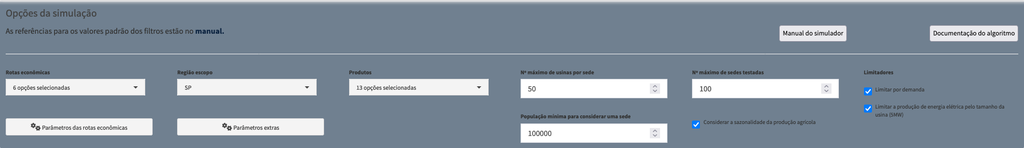

Captura de tela da página SIEnergia - Módulo Simulador - Opções da simulação

### Rotas econômicas

O parâmetro “Rotas econômicas” permite selecionar quais rotas serão simuladas. É necessário selecionar pelo menos uma rota, porém o filtro permite selecionar múltiplas rotas.

É possível selecionar as seguintes rotas econômicas:

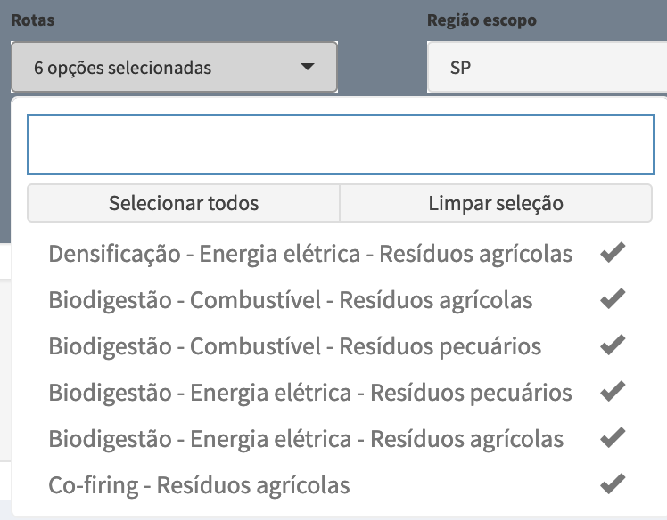

Captura de tela da página SIEnergia - Módulo Simulador - Opções da simulação - Rotas

### Região escopo

O parâmetro “Região escopo” permite selecionar quais regiões serão consideradas na simulação. O simulador considera a região selecionada como a região de origem dos produtos agropecuários. Por exemplo, se for selecionado o estado de São Paulo, o simulador considerará que os produtos agropecuários produzidos em São Paulo. Além disso, a região de escopo é importante para filtrar os dados relevantes para a simulação, como a demanda de energia elétrica e de combustível em cada município.

As opções são os estados brasileiros (selecionando a sigla da UF).

O valor padrão utilizado pelo simulador é “AC”, ou seja, o estado do Acre (por questões de ordem alfabética).

**Atenção**

O simulador pode demorar alguns minutos para ser executado quando a região escopo abrange muitas regiões.

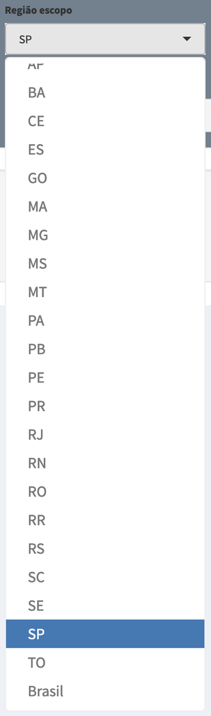

Captura de tela da página SIEnergia - Módulo Simulador - Opções da simulação - Regiões

### Produtos

Este parâmetro permite selecionar quais produtos serão utilizados na simulação. É necessário selecionar pelo menos um produto, porém o filtro permite selecionar múltiplos produtos.

Por padrão, todos os produtos são selecionados.

**Atenção**

Para que os produtos selecionados sejam considerados no simulador, pelo menos uma rota que utilize resíduos dos produtos escolhidos deve ser selecionada. Em caso de dúvidas, consulte a Seção 3.1.1.

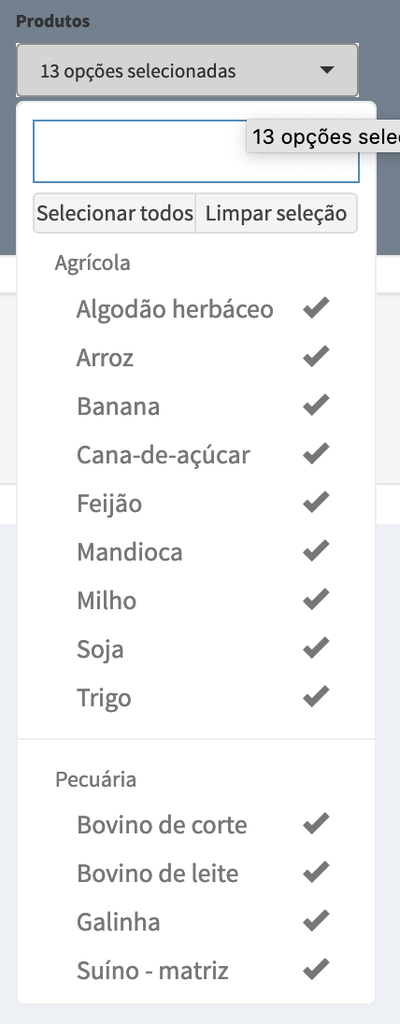

Captura de tela da página SIEnergia - Módulo Simulador - Opções da simulação - Produtos

### Número máximo de usinas por sede

Uma sede, no contexto do simulador, é uma região geográfica que pode abrigar uma ou mais usinas. Neste caso, cada sede é um município, chamado de “município sede” ou apenas “sede”.

O parâmetro “Número máximo de usinas por sede” permite limitar o número máximo de usinas que podem ser instaladas em uma mesma sede.

### Número máximo de sedes testadas

O parâmetro “Número máximo de sedes testadas” (`num_c`) permite limitar o número máximo de sedes que serão testadas pelo simulador. Por exemplo, caso `num_c` receba o número 5570 (o número de municípios do Brasil), o simulador poderá testar para cada município até 5570 possibilidades de fornecimento de energético. Ou seja, todas as possibilidades seriam contempladas.

Entretanto, é comum que a solução ótima esteja dentre as soluções mais lucrativas. O parâmetro `num_c` permite restringir essas comparações apenas às `num_c` relações de oferta de energético <-> consumo de energético que são mais lucrativas. Nossas análises de sensibilidade indicam que o valor `num_c = 100` é suficiente para a maior parte de cenários.

### População mínima para considerar uma sede

O simulador considera que uma sede só pode ser construída em um município que possui uma população mínima. O valor padrão é 100.000 habitantes.

### Considerar a sazonalidade da produção agrícola

Ao selecionar esta opção, o simulador irá considerar a sazonalidade da produção agrícola. A Tabela 1 apresenta os valores utilizados pelo simulador para cada combinação de produto, UF e mês.

Por padrão, esta opção está habilitada.

Tabela 1: Sazonalidade da produção agrícola, por UF/Produto/Mês

| UF | Produto | JAN | FEV | MAR | ABR | MAI | JUN | JUL | AGO | SET | OUT | NOV | DEZ | Total |
| --- | --- | --- | --- | --- | --- | --- | --- | --- | --- | --- | --- | --- | --- | --- |
| BA | Algodão herbáceo (em caroço) | 0% | 0% | 0% | 0% | 20% | 20% | 20% | 20% | 20% | 0% | 0% | 0% | 100% |
| CE | Algodão herbáceo (em caroço) | 0% | 0% | 0% | 0% | 0% | 33% | 33% | 33% | 0% | 0% | 0% | 0% | 100% |
| GO | Algodão herbáceo (em caroço) | 0% | 0% | 0% | 0% | 0% | 25% | 25% | 25% | 25% | 0% | 0% | 0% | 100% |
| MA | Algodão herbáceo (em caroço) | 0% | 0% | 0% | 0% | 0% | 25% | 25% | 25% | 25% | 0% | 0% | 0% | 100% |
| MG | Algodão herbáceo (em caroço) | 0% | 0% | 0% | 0% | 25% | 25% | 25% | 25% | 0% | 0% | 0% | 0% | 100% |
| MS | Algodão herbáceo (em caroço) | 0% | 0% | 0% | 20% | 20% | 20% | 20% | 20% | 0% | 0% | 0% | 0% | 100% |
| MT | Algodão herbáceo (em caroço) | 0% | 0% | 0% | 0% | 0% | 25% | 25% | 25% | 25% | 0% | 0% | 0% | 100% |
| PB | Algodão herbáceo (em caroço) | 0% | 0% | 0% | 0% | 0% | 0% | 25% | 25% | 25% | 25% | 0% | 0% | 100% |
| PI | Algodão herbáceo (em caroço) | 0% | 0% | 0% | 0% | 0% | 33% | 33% | 33% | 0% | 0% | 0% | 0% | 100% |
| PR | Algodão herbáceo (em caroço) | 0% | 0% | 0% | 25% | 25% | 25% | 25% | 0% | 0% | 0% | 0% | 0% | 100% |

[output cut: 135 more lines]

### Limitadores

Os filtros na seção “Limitadores” permitem limitar os resultados da simulação, de acordo com as opções selecionadas.

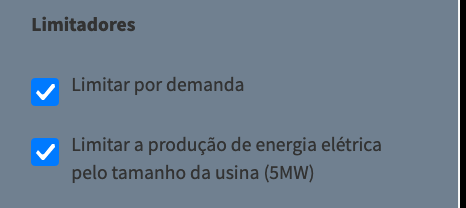

Captura de tela da página SIEnergia - Módulo Simulador - Opções da simulação - Limitadores

#### Limitar por demanda

Ao selecionar esta opção, o simulador irá limitar a quantidade de energia ou combustível gerada, de acordo com: (a) a demanda energética da distribuidora de energia elétrica responsável pelo atendimento da região escopo ou (b) a demanda por combustíveis veiculares no município sede ou (c) a demanda por combustível para queima em cimenteiras, usinas siderúrgicas e UTEs já existentes.

Por padrão, esta opção está habilitada.

#### Limitar a produção de energia elétrica pelo tamanho da usina (5MW)

Ao selecionar esta opção, o simulador irá limitar os resultados de rotas que geram energia elétrica para que as usinas sejam de microgeração, tendo uma potência instalada de até 5 MW.

Por padrão, esta opção está habilitada.

## Parâmetros das rotas econômicas

Os parâmetros das rotas econômicas são utilizados pelo simulador, e devem ser configurados para cada rota econômica. Os parâmetros são divididos em 5 grupos: econômicos, usina, obtenção do resíduo, transporte e demanda (este último apenas para a rota de co-firing).

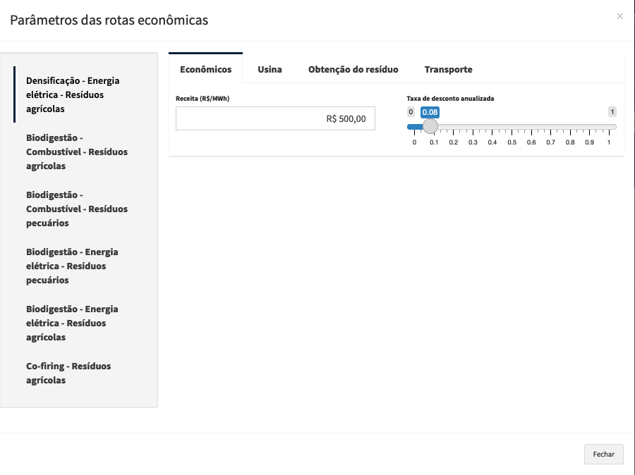

Captura de tela da página SIEnergia - Módulo Simulador - Opções da simulação - Parâmetros das rotas econômicas

### Econômicos

- **Receita:** Valor da receita obtida pela rentabilização: (a) nas rotas de energia elétrica, da energia elétrica gerada pela usina por compensação de energia gerada via MMGD; (b) nas rotas de combustível veicular da comercialização de biometano; ou (c) na rota de cofiring da comercialização do combustível.
- **Taxa de desconto anualizada:** Segundo (Crotman, 2019) esta taxa deve ser a taxa neutra a risco para uma efetiva avaliação do valor econômico de um ativo. A taxa neutra ao risco deve ser a soma da taxa livre de risco com um prêmio de risco. A estimação do prêmio de risco depende de fatores como a aversão a risco específica do investidor e a quantidade de risco não diversificável do investimento. Assim, qualquer investidor candidato pode avaliar o potencial do aproveitamento de resíduos, levando em conta suas próprias premissas de prêmio de risco exigido.

### Usina

- **Capex fixo:** Coeficiente linear da função Capex (função que transforma a potência de uma usina termoelétrica no seu custo). Veja equações 3.8 e 3.15 (Crotman, 2019).
- **Capex adicional:** Coeficiente angular da função Capex (função que transforma a potência de uma usina termoelétrica no seu custo). Veja páginas 36 e 39 (Crotman, 2019).
- **Percentual Opex:** Percentual do investimento inicial que representa o custo anual para operação e manutenção da usina. É o valor ‘fOpex’ da equação 3.12 (Crotman, 2019).
- **Eficiência da usina:** Eficiência da usina termelétrica, ou seja, a parcela de energia contida no resíduo que é efetivamente transformada em energia;
- **Vida útil da usina:** Número de anos de vida útil de uma usina.
- **Fator de disponibilidade da usina:** O fator de disponibilidade da usina termelétrica. Este fator representa qual fração de tempo uma termelétrica permanece funcionando durante um período longo. São descontados os períodos típicos de indisponibilidade não programada e manutenções programadas. Este parâmetro é adimensional.

### Obtenção do resíduo

- **Custo de coleta:** Custo de se coletar o resíduo e levar até 15km de distância (R$/tonelada). É o valor ‘Colheita’ da equação 3.11 (Crotman, 2019).
- **Custo de armazenamento:** Custo de armazenamento (R$/tonelada). É o valor ‘Armaz’ da equação 3.11 (Crotman, 2019).
- **Custo de carga e descarga do resíduo:** Custo de carga e descarga de todo o processo desde a coleta do resíduo na sua origem até a entrega na usina termelétrica (R$/tonelada). É o valor ‘Carga’ da equação 3.11 (Crotman, 2019).
- **Prêmio para o produtor:** Prêmio oferecido ao produtor pelo fornecimento do resíduo em % no caso de percentual do custo logístico ou reais por tonelada no caso de percentual do valor de mercado. É o valor ‘Prêmio_c’ da equação 3.10 (Crotman, 2019).

### Transporte

- **Custo fixo de transporte:** Custo fixo de remuneração do tranposrte por 1 km. Essa quantidade representa a quantidade em R$ por quilômetro que seria considerada para transportar valores muito pequenos de biomassa.
- **Custo de transporte:** Custo de transporte entre o município de origem do resíduo e o local onde está a usina termelétrica (R$ por tonelada por quilômetro). É o valor ‘Transp’ da equação 3.11 (Crotman, 2019).

### Demanda (apenas para Co-firing)

- **Demanda de termelétrica:** % da demanda por combustíveis de UTEs que poderia ser substituída por briquete ou pellets, valor entre 0 e 100%.
- **Demanda siderúrgica:** % da demanda por combustíveis de siderúrgicas que poderia ser substituída por briquete ou pellets, valor entre 0 e 100%.
- **Demanda cimenteira:** % da demanda por combustíveis de cimenteiras que poderia ser substituída por briquete ou pellets, valor entre 0 e 100%.

## Parâmetros extras

### Transporte

- **Considerar frete para ida e volta no cálculo do combustível consumido e distância percorrida** - Ao selecionar esta opção, o simulador irá considerar que o caminhão que transporta o resíduo irá retornar vazio para a origem, após descarregar o resíduo na usina, e portanto irá considerar o dobro da distância percorrida e do combustível consumido. Essa opção está habilitada por padrão.

### Externalidades

- **Empregos**: fator de empregabilidade por unidade de energia gerada e fator de remuneração pessoal. Fatores calculados a partir de dados obtidos em [IRENA](https://www.irena.org/Data/View-data-by-topic/Benefits/Renewable-Energy-Employment-by-Country), referente à 2022.
- **Consumo de água** - fator de consumo de água por unidade de energia gerada. Fatores calculados a partir de dados obtidos em: [Conde (2013, p. 63)](https://www.ppe.ufrj.br/images/publica%C3%A7%C3%B5es/mestrado/Marcos_Ribeiro_Conde.pdf).
- **Emissões** - fator de emissões por unidade de energia gerada. Fatores calculados a partir de dados obtidos em [IRENA](https://www.irena.org/Data/View-data-by-topic/Climate-Change/Avoided-Emissions-Calculator).

# Execução do Simulador

O simulador pode demorar alguns minutos para realizar a simulação, dependendo dos parâmetros selecionados. Durante a execução, o simulador irá exibir uma barra de progresso, indicando o andamento da simulação.

Após realizar a simulação, o simulador irá exibir os resultados na tela. Para mais informações sobre os resultados, consulte a Seção 5.

# Apresentação dos Resultados

Os resultados da simulação são apresentados em diferentes formas, como caixas com valores sumarizados, mapas e tabelas. A seguir, são descritos os principais resultados apresentados pelo simulador.

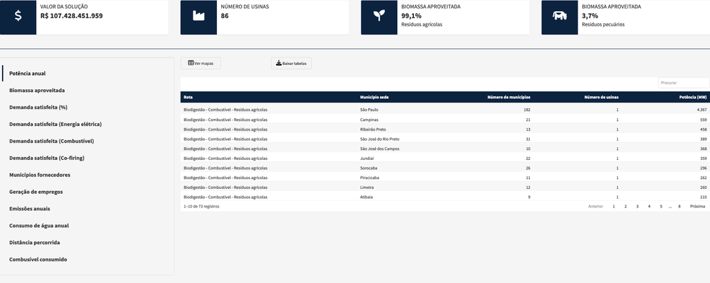

Captura de tela da página SIEnergia - Módulo Simulador - Resultados

## Caixas com valores sumarizados

A primeira seção de resultados apresenta alguns valores sumarizados em caixas, como:

- o valor da solução encontrada (em R$);
- o número de usinas a serem contruídas, segundo os resultados da simulação;
- a porcentagem de biomassa de resíduos agrícolas aproveitada;
- a porcentagem de biomassa de resíduos pecuários aproveitada.

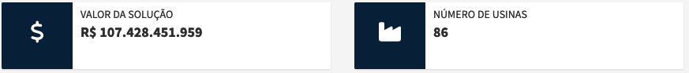

Exemplo de Resultados apresentados como valores sumarizados: valor da solução e número de usinas.

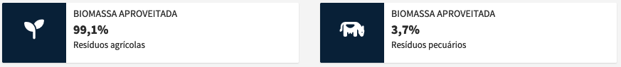

Exemplo de Resultados apresentados como valores sumarizados: Biomassa aproveitada.

## Mapas

Para acessar os mapas, é necessário clicar em “Ver mapas”.

Os mapas apresentam os resultados da simulação, separados por rota econômica. No menu lateral da aba de Mapas, aparece uma opção para cada rota econômica.

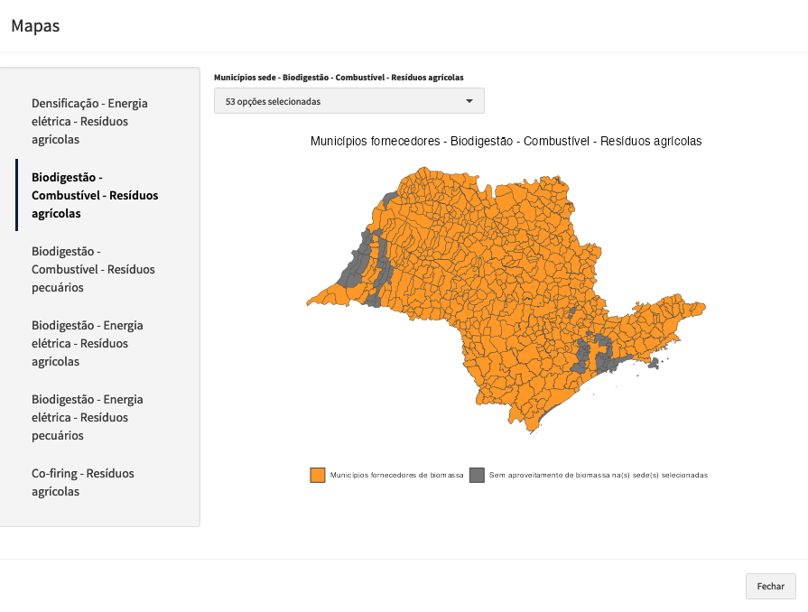

Captura de tela da página SIEnergia - Módulo Simulador - Resultados - Mapas

No mapa por rota, há um menu com uma lista de nomes de municípios. Ao clicar em um município sede, o mapa irá exibir os municípios fornecedores de biomassa para a(s) sede(s) selecionada(s).

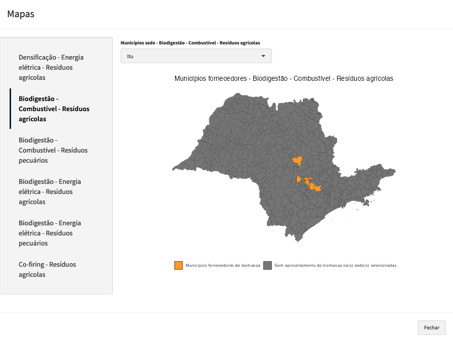

Captura de tela da página SIEnergia - Módulo Simulador - Resultados - Mapas - Selecionando apenas uma sede

## Tabelas

É possível fazer download das tabelas com os resultados da simulação, clicando em “Baixar tabelas”.

As tabelas apresentam os resultados da simulação, considerando diversos aspectos, como:

- Potência instalada
- Investimentos
- Biomassa aproveitada
- Municípios fornecedores
- Demanda satisfeita (%), Demanda satisfeita (Energia elétrica), Demanda satisfeita (Combustível), Demanda satisfeita (Co-firing)
- Externalidades: Geração de empregos, Emissões anuais, Consumo de água anual
- Distância percorrida
- Combustível consumido

# Fonte dos Dados

Existem várias fontes de dados utilizadas pelo simulador. A seguir, são listadas os principais dados utilizadas pelo simulador e suas respectivas fontes. Caso tenha dúvidas, acesse Seção 7 e entre em contato com a equipe da EPE.

- Produção agropecuária: Instituto Brasileiro de Geografia e Estatística (IBGE), através do Sistema IBGE de Recuperação Automática (SIDRA)
- População municipal: Instituto Brasileiro de Geografia e Estatística (IBGE)
- Distância entre municípios: dados obtidos usando a API do Open Source Routing Machine (ORSM).
- Demanda de energia elétrica: Agência Nacional de Energia Elétrica (ANEEL)
- Demanda de combustíveis (gasolina e diesel): Agência Nacional do Petróleo, Gás Natural e Biocombustíveis (ANP)
- Demanda de co-firing: Levantamentos realizados pela EPE
- Sazonalidade da venda de combustíveis: Agência Nacional do Petróleo, Gás Natural e Biocombustíveis (ANP)
- Sazonalidade da produção agrícola: Levantamentos realizados pela EPE

# Suporte e Contato

Em caso de dúvidas, entre em contato com a equipe de coordenação técnica do SIEnergia através do e-mail:

- **Luciano Basto Oliveira** - luciano.oliveira@epe.gov.br
- **Daniel Kühner Coelho** - daniel.coelho@epe.gov.br

## Referências citadas

CROTMAN, BRUNO MAURICIO RODRIGUES. **Avaliação da geração de energia a partir de resíduos no Brasil usando otimização heurística.** 2019. Dissertação de mestrado. UNIVERSIDADE FEDERAL DO ESTADO DO RIO DE JANEIRO, Rio de Janeiro. Acesso em: https://ppgi.uniriotec.br/download/3080/?tmstv=1703009394

CONDE, MARCOS RIBEIRO. **Incorporação da dimensão ambiental no planejamento de longo prazo da expensão da geração de energia elétrica por meio de técnicas multicritério de apoio a tomada de decisão.** 2013. Dissertação de mestrado. UNIVERSIDADE FEDERAL DO RIO DE JANEIRO, Rio de Janeiro. Acesso em: https://www.ppe.ufrj.br/images/publica%C3%A7%C3%B5es/mestrado/Marcos_Ribeiro_Conde.pdf